# PART 1 - PLOTTING THE APARTMENT SALES PRICE ON CHOROPLETH

```python
import numpy as np # library to handle data in a vectorized manner

import pandas as pd # library for data analsysis
pd.set_option('display.max_columns', None)
pd.set_option('display.max_rows', None)

import json # library to handle JSON files

#!conda install -c conda-forge geopy --yes # uncomment this line if you haven't completed the Foursquare API lab
from geopy.geocoders import Nominatim # convert an address into latitude and longitude values

import requests # library to handle requests
from pandas.io.json import json_normalize # tranform JSON file into a pandas dataframe

# Matplotlib and associated plotting modules
import matplotlib.cm as cm
import matplotlib.colors as colors

import matplotlib.pyplot as plt
%matplotlib inline

# import k-means from clustering stage
from sklearn.cluster import KMeans

#!conda install -c conda-forge folium=0.5.0 --yes # uncomment this line if you haven't completed the Foursquare API lab
import folium # map rendering library

print('Libraries imported.')
```

```
Libraries imported.
```

```python
CLIENT_ID = 'HMJSQ3GVV5LKNSTVIMD1DZYOS1E2WPOYUF43FCPWX4QNKLFW' # your Foursquare ID
CLIENT_SECRET = 'PWDCF25ERDO4YXDNO4IINJGEKEOBCJO2P0WSGINATUEJWIGR' # your Foursquare Secret
VERSION = '20180605' # Foursquare API version

print('Your credentails:')
print('CLIENT_ID: ' + CLIENT_ID)
print('CLIENT_SECRET:' + CLIENT_SECRET)
```

```
Your credentails:
CLIENT_ID: HMJSQ3GVV5LKNSTVIMD1DZYOS1E2WPOYUF43FCPWX4QNKLFW
CLIENT_SECRET:PWDCF25ERDO4YXDNO4IINJGEKEOBCJO2P0WSGINATUEJWIGR
```

```python
df=pd.read_excel('rollingsales_manhattan.xls',skiprows=4)
df.head()
```

|  | BOROUGH | NEIGHBORHOOD | BUILDING CLASS CATEGORY | TAX CLASS AT PRESENT | BLOCK | LOT | EASE-MENT | BUILDING CLASS AT PRESENT | ADDRESS | APARTMENT NUMBER | ZIP CODE | RESIDENTIAL UNITS | COMMERCIAL UNITS | TOTAL UNITS | LAND SQUARE FEET | GROSS SQUARE FEET | YEAR BUILT | TAX CLASS AT TIME OF SALE | BUILDING CLASS AT TIME OF SALE | SALE PRICE | SALE DATE |
| --- | --- | --- | --- | --- | --- | --- | --- | --- | --- | --- | --- | --- | --- | --- | --- | --- | --- | --- | --- | --- | --- |
| 0 | 1 | ALPHABET CITY | 01 ONE FAMILY DWELLINGS | 1 | 400 | 19 | NaN | A4 | 526 EAST 5TH STREET | NaN | 10009 | 1.0 | 0.0 | 1.0 | 1883.0 | 5200.0 | 1900 | 1 | A4 | 6100000 | 2018-12-03 |
| 1 | 1 | ALPHABET CITY | 02 TWO FAMILY DWELLINGS | 1 | 404 | 1 | NaN | B9 | 166 AVENUE A | NaN | 10009 | 2.0 | 0.0 | 2.0 | 1510.0 | 4520.0 | 1900 | 1 | B9 | 0 | 2018-11-29 |
| 2 | 1 | ALPHABET CITY | 02 TWO FAMILY DWELLINGS | 1 | 404 | 1 | NaN | B9 | 166 AVENUE A | NaN | 10009 | 2.0 | 0.0 | 2.0 | 1510.0 | 4520.0 | 1900 | 1 | B9 | 0 | 2018-11-29 |
| 3 | 1 | ALPHABET CITY | 03 THREE FAMILY DWELLINGS | 1 | 377 | 56 | NaN | C0 | 263 EAST 7TH STREET | NaN | 10009 | 3.0 | 0.0 | 3.0 | 2430.0 | 3600.0 | 1899 | 1 | C0 | 6300000 | 2019-04-30 |
| 4 | 1 | ALPHABET CITY | 07 RENTALS - WALKUP APARTMENTS | 2 | 373 | 19 | NaN | C7 | 332 EAST 4TH STREET | NaN | 10009 | 28.0 | 2.0 | 30.0 | 4651.0 | 17478.0 | 1920 | 2 | C7 | 14000000 | 2019-01-09 |

```python
df.columns
```

[output not shown]

## Data Cleaning

### Let's first replace 0 with NaN

```python
df['RESIDENTIAL UNITS'].replace(0,np.nan,inplace=True)
df['SALE PRICE'].replace(0,np.nan,inplace=True)
df['GROSS SQUARE FEET'].replace(0,np.nan,inplace=True)
```

### Check the null values

```python
missing_data = df.isnull()
missing_data.head(10)
```

|  | BOROUGH | NEIGHBORHOOD | BUILDING CLASS CATEGORY | TAX CLASS AT PRESENT | BLOCK | LOT | EASE-MENT | BUILDING CLASS AT PRESENT | ADDRESS | APARTMENT NUMBER | ZIP CODE | RESIDENTIAL UNITS | COMMERCIAL UNITS | TOTAL UNITS | LAND SQUARE FEET | GROSS SQUARE FEET | YEAR BUILT | TAX CLASS AT TIME OF SALE | BUILDING CLASS AT TIME OF SALE | SALE PRICE | SALE DATE |
| --- | --- | --- | --- | --- | --- | --- | --- | --- | --- | --- | --- | --- | --- | --- | --- | --- | --- | --- | --- | --- | --- |
| 0 | False | False | False | False | False | False | True | False | False | True | False | False | False | False | False | False | False | False | False | False | False |
| 1 | False | False | False | False | False | False | True | False | False | True | False | False | False | False | False | False | False | False | False | True | False |
| 2 | False | False | False | False | False | False | True | False | False | True | False | False | False | False | False | False | False | False | False | True | False |
| 3 | False | False | False | False | False | False | True | False | False | True | False | False | False | False | False | False | False | False | False | False | False |
| 4 | False | False | False | False | False | False | True | False | False | True | False | False | False | False | False | False | False | False | False | False | False |
| 5 | False | False | False | False | False | False | True | False | False | True | False | False | False | False | False | False | False | False | False | False | False |
| 6 | False | False | False | False | False | False | True | False | False | True | False | False | False | False | False | False | False | False | False | False | False |
| 7 | False | False | False | False | False | False | True | False | False | True | False | False | False | False | False | False | False | False | False | False | False |
| 8 | False | False | False | False | False | False | True | False | False | True | False | False | False | False | False | False | False | False | False | True | False |
| 9 | False | False | False | False | False | False | True | False | False | True | False | False | False | False | False | False | False | False | False | False | False |

```python
for column in missing_data.columns.values.tolist():
    print(column)
    print (missing_data[column].value_counts())
    print("")
```

```
BOROUGH
False    16875
Name: BOROUGH, dtype: int64

NEIGHBORHOOD
False    16875
Name: NEIGHBORHOOD, dtype: int64

BUILDING CLASS CATEGORY
False    16875
Name: BUILDING CLASS CATEGORY, dtype: int64

TAX CLASS AT PRESENT
False    16875
Name: TAX CLASS AT PRESENT, dtype: int64

BLOCK
False    16875
Name: BLOCK, dtype: int64

LOT
False    16875
Name: LOT, dtype: int64

EASE-MENT
True    16875
Name: EASE-MENT, dtype: int64

BUILDING CLASS AT PRESENT
False    16875
Name: BUILDING CLASS AT PRESENT, dtype: int64

ADDRESS
False    16875
Name: ADDRESS, dtype: int64

APARTMENT NUMBER
True     8930
False    7945
Name: APARTMENT NUMBER, dtype: int64
```

[output cut: 35 more lines]

```
False    16875
Name: TAX CLASS AT TIME OF SALE, dtype: int64

BUILDING CLASS AT TIME OF SALE
False    16875
Name: BUILDING CLASS AT TIME OF SALE, dtype: int64

SALE PRICE
False    13233
True      3642
Name: SALE PRICE, dtype: int64

SALE DATE
False    16875
Name: SALE DATE, dtype: int64
```

### Keep the residential apartment data and rows with 'SALE PRICE' value

**The relationship between ['RESIDENTIAL UNITS'] and ['COMMERCIAL UNITS']**  
Generally, if the value in ['COMMERCIAL UNITS'] is null, that in ['RESIDENTIAL UNITS'] is not null, and vice versa. In another words, these 2 columns tell us if an apartment is (mainly) residential or commercial. Since we only want to analyze residential apartments, we will drop all rows containing commercial apartment data.

In the meanwhile, SALE PRICE data are absent in some rows. Since price is our target variable, let's drow those rows.

```python
# simply drop whole row with NaN in "RESIDENTIAL UNITS" and "SALE PRICE" column
df.dropna(subset=["RESIDENTIAL UNITS"], axis=0, inplace=True)
df.dropna(subset=["SALE PRICE"], axis=0, inplace=True)

# reset index, because we droped wo rows
df.reset_index(drop=True, inplace=True)
```

```python
missing_data = df.isnull()

for column in missing_data.columns.values.tolist():
    print(column)
    print (missing_data[column].value_counts())
    print("")
```

```
BOROUGH
False    785
Name: BOROUGH, dtype: int64

NEIGHBORHOOD
False    785
Name: NEIGHBORHOOD, dtype: int64

BUILDING CLASS CATEGORY
False    785
Name: BUILDING CLASS CATEGORY, dtype: int64

TAX CLASS AT PRESENT
False    785
Name: TAX CLASS AT PRESENT, dtype: int64

BLOCK
False    785
Name: BLOCK, dtype: int64

LOT
False    785
Name: LOT, dtype: int64

EASE-MENT
True    785
Name: EASE-MENT, dtype: int64

BUILDING CLASS AT PRESENT
False    785
Name: BUILDING CLASS AT PRESENT, dtype: int64

ADDRESS
False    785
Name: ADDRESS, dtype: int64

APARTMENT NUMBER
True     780
False      5
Name: APARTMENT NUMBER, dtype: int64
```

[output cut: 29 more lines]

```
TAX CLASS AT TIME OF SALE
False    785
Name: TAX CLASS AT TIME OF SALE, dtype: int64

BUILDING CLASS AT TIME OF SALE
False    785
Name: BUILDING CLASS AT TIME OF SALE, dtype: int64

SALE PRICE
False    785
Name: SALE PRICE, dtype: int64

SALE DATE
False    785
Name: SALE DATE, dtype: int64
```

### Eliminate outliers

Now that we got rid of all the null values, let's create our target column: ['PRICE PER SQUARE FOOT'], and also eliminate the outliers so that our Choropleth can be more representative.

```python
df['PRICE PER SQUARE FOOT'] = df['SALE PRICE'] / df['GROSS SQUARE FEET']
```

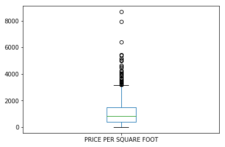

```python
df['PRICE PER SQUARE FOOT'].plot(kind='box')
```

```python
df['PRICE PER SQUARE FOOT'].describe(include='all')
```

```
count     785.000000
mean     1115.628289
std      1063.782963
min         0.000051
25%       402.500977
50%       813.358681
75%      1506.823351
max      8670.886076
Name: PRICE PER SQUARE FOOT, dtype: float64
```

```python
iqr = 1506.823351 - 402.500977
iqr
```

```
1104.322374
```

```python
outlier1 = 402.500977 - 1.5*iqr
outlier1
```

```
-1253.982584
```

```python
outlier2 = 1506.823351 + 1.5*iqr
outlier2
```

```
3163.306912
```

```python
# Get names of indexes for outliers in column PRICE PER SQUARE FEET
indexNames = df[ df['PRICE PER SQUARE FOOT'] > outlier2 ].index

# Delete these row indexes from dataFrame
df.drop(indexNames , inplace=True)
```

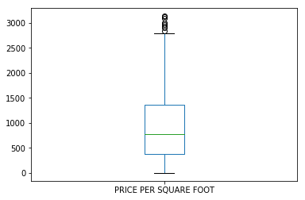

```python
df['PRICE PER SQUARE FOOT'].plot(kind='box')
```

```python
df.info()
```

```
<class 'pandas.core.frame.DataFrame'>
Int64Index: 745 entries, 0 to 784
Data columns (total 22 columns):
BOROUGH                           745 non-null int64
NEIGHBORHOOD                      745 non-null object
BUILDING CLASS CATEGORY           745 non-null object
TAX CLASS AT PRESENT              745 non-null object
BLOCK                             745 non-null int64
LOT                               745 non-null int64
EASE-MENT                         0 non-null float64
BUILDING CLASS AT PRESENT         745 non-null object
ADDRESS                           745 non-null object
APARTMENT NUMBER                  4 non-null object
ZIP CODE                          745 non-null int64
RESIDENTIAL UNITS                 745 non-null float64
COMMERCIAL UNITS                  745 non-null float64
TOTAL UNITS                       745 non-null float64
LAND SQUARE FEET                  745 non-null float64
GROSS SQUARE FEET                 745 non-null float64
YEAR BUILT                        745 non-null int64
TAX CLASS AT TIME OF SALE         745 non-null int64
BUILDING CLASS AT TIME OF SALE    745 non-null object
SALE PRICE                        745 non-null float64
SALE DATE                         745 non-null datetime64[ns]
PRICE PER SQUARE FOOT             745 non-null float64
dtypes: datetime64[ns](1), float64(8), int64(6), object(7)
memory usage: 133.9+ KB
```

### Matching df['NEIGHBORHOOD'] and the neighborhoods in the GeoJson file

df['NEIGHBORHOOD'] is in fact different from the neighborhoods in the GeoJson file. The majority of neighborhoods in these 2 files are different while only a small number of them are exact match. In order to map the Choropleth correctly, we have to match each and every apartment in df with the neighborhood in the GeoJson file.

### 1. Create a new column ['FULL ADDRESS']

```python
df['NEIGHBORHOOD'] = df['NEIGHBORHOOD'].apply(lambda x: x.title())
df['NEIGHBORHOOD'].sample(5)
```

```
170     Greenwich Village-West
343                Harlem-East
13               Alphabet City
601    Upper East Side (59-79)
98                    Gramercy
Name: NEIGHBORHOOD, dtype: object
```

```python
df['FULL ADDRESS']=df['ADDRESS']+', '+df['NEIGHBORHOOD']+', Manhattan, NY, USA'
df['FULL ADDRESS'].sample(2)
```

```
705    310 WEST 82ND STREET, Upper West Side (79-96),...
599    715 MADISON AVENUE, Upper East Side (59-79), M...
Name: FULL ADDRESS, dtype: object
```

### 2. Get geographic coordinates for all the apartments

```python
! pip install geocoder
```

```python
import requests
import logging
import time

logger = logging.getLogger("root")
logger.setLevel(logging.DEBUG)

# create console handler
ch = logging.StreamHandler()
ch.setLevel(logging.DEBUG)
logger.addHandler(ch)
```

```python
# Set your Google API key here.

# Even if using the free 2500 queries a day, its worth getting an API key since the rate limit is 50 / second.
# With API_KEY = None, you will run into a 2 second delay every 10 requests or so.
# With a "Google Maps Geocoding API" key from https://console.developers.google.com/apis/,
# the daily limit will be 2500, but at a much faster rate.
# Example: API_KEY = 'AIzaSyC9azed9tLdjpZNjg2_kVePWvMIBq154eA'
API_KEY = 'AIzaSyCvBck-H6M_xSPAXbw9tAP8-aF-G2uwZJ0'
# Backoff time sets how many minutes to wait between google pings when your API limit is hit
BACKOFF_TIME = 30
# Set your output file name here.
output_filename = 'geo.csv'
# Set your input file here
input_filename = df
# Specify the column name in your input data that contains addresses here
address_column_name = "FULL ADDRESS"
# Return Full Google Results? If True, full JSON results from Google are included in output
RETURN_FULL_RESULTS = False
```

```python
# Make a big list of all of the addresses to be processed.
addresses = df['FULL ADDRESS'].tolist()
```

```python
def get_google_results(address, api_key=None, return_full_response=False):
    """
    Get geocode results from Google Maps Geocoding API.

    Note, that in the case of multiple google geocode reuslts, this function returns details of the FIRST result.

    @param address: String address as accurate as possible. For Example "18 Grafton Street, Dublin, Ireland"
    @param api_key: String API key if present from google.
                    If supplied, requests will use your allowance from the Google API. If not, you
                    will be limited to the free usage of 2500 requests per day.
    @param return_full_response: Boolean to indicate if you'd like to return the full response from google. This
                    is useful if you'd like additional location details for storage or parsing later.
    """
    # Set up your Geocoding url
    geocode_url = "https://maps.googleapis.com/maps/api/geocode/json?address={}".format(address)
    if api_key is not None:
        geocode_url = geocode_url + "&key={}".format(api_key)

    # Ping google for the reuslts:
    results = requests.get(geocode_url)
    # Results will be in JSON format - convert to dict using requests functionality
    results = results.json()

    # if there's no results or an error, return empty results.
    if len(results['results']) == 0:
        output = {
            "formatted_address" : None,
            "latitude": None,
            "longitude": None,
            "accuracy": None,
            "google_place_id": None,
            "type": None,
            "postcode": None
        }
    else:
        answer = results['results'][0]
        output = {
            "formatted_address" : answer.get('formatted_address'),
            "latitude": answer.get('geometry').get('location').get('lat'),
            "longitude": answer.get('geometry').get('location').get('lng'),
            "accuracy": answer.get('geometry').get('location_type'),
            "google_place_id": answer.get("place_id"),
            "type": ",".join(answer.get('types')),
            "postcode": ",".join([x['long_name'] for x in answer.get('address_components')
                                  if 'postal_code' in x.get('types')])
        }

    # Append some other details:
    output['input_string'] = address
    output['number_of_results'] = len(results['results'])
    output['status'] = results.get('status')
    if return_full_response is True:
        output['response'] = results

    return output
```

# Don't run the following code!!

This block of code will extract geographic coordinates for all the apartments, however, it will run for 20-30 minutes everytime we restart the kernel.

After running this block of code once, I have all the coordinates saved to a CSV file.

```python
# Create a list to hold results
results = []
# Go through each address in turn
for address in addresses:
    # While the address geocoding is not finished:
    geocoded = False
    while geocoded is not True:
        # Geocode the address with google
        try:
            geocode_result = get_google_results(address, API_KEY, return_full_response=RETURN_FULL_RESULTS)
        except Exception as e:
            logger.exception(e)
            logger.error("Major error with {}".format(address))
            logger.error("Skipping!")
            geocoded = True

        # If we're over the API limit, backoff for a while and try again later.
        if geocode_result['status'] == 'OVER_QUERY_LIMIT':
            logger.info("Hit Query Limit! Backing off for a bit.")
            time.sleep(BACKOFF_TIME * 60) # sleep for 30 minutes
            geocoded = False
        else:
            # If we're ok with API use, save the results
            # Note that the results might be empty / non-ok - log this
            if geocode_result['status'] != 'OK':
                logger.warning("Error geocoding {}: {}".format(address, geocode_result['status']))
            logger.debug("Geocoded: {}: {}".format(address, geocode_result['status']))
            results.append(geocode_result)
            geocoded = True

    # Print status every 100 addresses
    if len(results) % 100 == 0:
    	logger.info("Completed {} of {} address".format(len(results), len(addresses)))

    # Every 500 addresses, save progress to file(in case of a failure so you have something!)
    if len(results) % 500 == 0:
        pd.DataFrame(results).to_csv("{}_bak".format(output_filename))

# All done
logger.info("Finished geocoding all addresses")
# Write the full results to csv using the pandas library.
pd.DataFrame(results).to_csv(output_filename, encoding='utf8')
```

### 3. Import the CSV file generated and merge with df

```python
mn=pd.read_csv('Manhattan geo.csv')
mn.head()
```

|  | Unnamed: 0 | accuracy | formatted_address | google_place_id | input_string | latitude | longitude | number_of_results | postcode | status | type |
| --- | --- | --- | --- | --- | --- | --- | --- | --- | --- | --- | --- |
| 0 | 0 | ROOFTOP | 526 E 5th St, New York, NY 10009, USA | ChIJTwc-n4JZwokRVDQmrfd1Kik | 526 EAST 5TH STREET, Alphabet City, Manhattan,... | 40.724206 | -73.983263 | 1 | 10009.0 | OK | premise |
| 1 | 1 | ROOFTOP | 263 E 7th St, New York, NY 10009, USA | ChIJ3QQl9HlZwokRvK8T2VsWAT0 | 263 EAST 7TH STREET, Alphabet City, Manhattan,... | 40.723652 | -73.977354 | 1 | 10009.0 | OK | street_address |
| 2 | 2 | ROOFTOP | 332 E 4th St, New York, NY 10009, USA | ChIJneNrEXlZwokR_oKjvGzEe1o | 332 EAST 4TH STREET, Alphabet City, Manhattan,... | 40.721556 | -73.979036 | 1 | 10009.0 | OK | premise |
| 3 | 3 | ROOFTOP | 253 E 7th St, New York, NY 10009, USA | ChIJIeYfwXFZwokRWT5opQGzLY8 | 275 EAST 7TH STREET, GD, Alphabet City, Manhat... | 40.723828 | -73.977776 | 1 | 10009.0 | OK | establishment,point_of_interest |
| 4 | 4 | GEOMETRIC_CENTER | Tompkins Square Park, E 10th St, New York, NY ... | ChIJgTDll51ZwokRVjN7KXztwXY | 434 EAST 10TH STREET, 4, Alphabet City, Manhat... | 40.726429 | -73.981784 | 1 | 10009.0 | OK | establishment,park,point_of_interest |

```python
mn = mn[['input_string','latitude','longitude']]
mn.head()
```

|  | input_string | latitude | longitude |
| --- | --- | --- | --- |
| 0 | 526 EAST 5TH STREET, Alphabet City, Manhattan,... | 40.724206 | -73.983263 |
| 1 | 263 EAST 7TH STREET, Alphabet City, Manhattan,... | 40.723652 | -73.977354 |
| 2 | 332 EAST 4TH STREET, Alphabet City, Manhattan,... | 40.721556 | -73.979036 |
| 3 | 275 EAST 7TH STREET, GD, Alphabet City, Manhat... | 40.723828 | -73.977776 |
| 4 | 434 EAST 10TH STREET, 4, Alphabet City, Manhat... | 40.726429 | -73.981784 |

```python
mn.rename(columns={'input_string':'FULL ADDRESS'}, inplace=True)
mn.info()
```

```
<class 'pandas.core.frame.DataFrame'>
RangeIndex: 745 entries, 0 to 744
Data columns (total 3 columns):
FULL ADDRESS    745 non-null object
latitude        745 non-null float64
longitude       745 non-null float64
dtypes: float64(2), object(1)
memory usage: 17.6+ KB
```

```python
dfa = df.drop_duplicates(subset=['FULL ADDRESS'])
dfb = mn.drop_duplicates(subset=['FULL ADDRESS'])

df1 = pd.merge(dfa, dfb, how='inner', on='FULL ADDRESS')
```

```python
df1.shape
```

```
(736, 25)
```

### Moving on, we will be using df1 instead of df

### 4. Match each row with the correct neighborhood in the GeoJSON file

#### First - Set the GeoJSON file to Manhattan only

```python
import json

with open('Neighborhood Tabulation Areas.geojson') as f:
    jsdata = json.load(f)
```

```python
# keep Manhattan only data

new_features = []
for element in jsdata["features"]:
    if 'Manhattan' in element['properties']['boro_name']:
        new_features.append(element)                # new_features has the one's you want
# and then re-assign features to the list with the elements you want
jsdata["features"] = new_features
```

```python
# check if the geojson file is Manhattan only

# assign relevant part of JSON to test
test = jsdata['features']

# tranform venues into a dataframe
dataframe = json_normalize(test)
dataframe['properties.boro_name'].value_counts()
```

```
Manhattan    29
Name: properties.boro_name, dtype: int64
```

#### Second - Find out the neighborhoods for all apartments

```python
# !pip install shapely[vectorized]

from shapely.geometry import Point, shape
from shapely.geometry.polygon import Polygon

# shapely documentation
# https://shapely.readthedocs.io/en/latest/manual.html
```

```python
results=[]
i=0

length = len(df1['FULL ADDRESS'])

while i < length:
    # construct point based on lat/long returned by geocoder
    point = Point(df1['longitude'][i], df1['latitude'][i])


    # check each polygon to see if it contains the point
    for feature in jsdata['features']:
        polygon = shape(feature['geometry'])
        if polygon.contains(point):
            results.append(feature)

    i=i+1
```

```python
results = pd.DataFrame(results)
```

```python
results.info()
```

```
<class 'pandas.core.frame.DataFrame'>
RangeIndex: 736 entries, 0 to 735
Data columns (total 3 columns):
type          736 non-null object
properties    736 non-null object
geometry      736 non-null object
dtypes: object(3)
memory usage: 17.4+ KB
```

```python
results.head()
```

|  | type | properties | geometry |
| --- | --- | --- | --- |
| 0 | Feature | {'ntacode': 'MN22', 'shape_area': '10894316.12... | {'type': 'MultiPolygon', 'coordinates': [[[[-7... |
| 1 | Feature | {'ntacode': 'MN28', 'shape_area': '23297284.60... | {'type': 'MultiPolygon', 'coordinates': [[[[-7... |
| 2 | Feature | {'ntacode': 'MN28', 'shape_area': '23297284.60... | {'type': 'MultiPolygon', 'coordinates': [[[[-7... |
| 3 | Feature | {'ntacode': 'MN28', 'shape_area': '23297284.60... | {'type': 'MultiPolygon', 'coordinates': [[[[-7... |
| 4 | Feature | {'ntacode': 'MN22', 'shape_area': '10894316.12... | {'type': 'MultiPolygon', 'coordinates': [[[[-7... |

```python
results1 = results['properties'].to_dict()
results1
```

```python
results2 = pd.DataFrame(results1)
```

```python
results3= results2.transpose()
results3.head()
```

|  | ntacode | shape_area | county_fips | ntaname | shape_leng | boro_name | boro_code |
| --- | --- | --- | --- | --- | --- | --- | --- |
| 0 | MN22 | 10894316.1206 | 061 | East Village | 13555.2394514 | Manhattan | 1 |
| 1 | MN28 | 23297284.6034 | 061 | Lower East Side | 25466.6913743 | Manhattan | 1 |
| 2 | MN28 | 23297284.6034 | 061 | Lower East Side | 25466.6913743 | Manhattan | 1 |
| 3 | MN28 | 23297284.6034 | 061 | Lower East Side | 25466.6913743 | Manhattan | 1 |
| 4 | MN22 | 10894316.1206 | 061 | East Village | 13555.2394514 | Manhattan | 1 |

```python
results4 = pd.DataFrame(results3['ntaname'])
results4.head()
```

|  | ntaname |
| --- | --- |
| 0 | East Village |
| 1 | Lower East Side |
| 2 | Lower East Side |
| 3 | Lower East Side |
| 4 | East Village |

#### Finally - Merge the result and df1

```python
frames = [df1, results4]

df2 = pd.concat(frames, sort=False, axis=1)
```

**Check the result**

```python
df2.shape
```

```
(736, 26)
```

```python
results4.info()
```

```
<class 'pandas.core.frame.DataFrame'>
Int64Index: 736 entries, 0 to 735
Data columns (total 1 columns):
ntaname    736 non-null object
dtypes: object(1)
memory usage: 11.5+ KB
```

```python
df2.head()
```

|  | BOROUGH | NEIGHBORHOOD | BUILDING CLASS CATEGORY | TAX CLASS AT PRESENT | BLOCK | LOT | EASE-MENT | BUILDING CLASS AT PRESENT | ADDRESS | APARTMENT NUMBER | ZIP CODE | RESIDENTIAL UNITS | COMMERCIAL UNITS | TOTAL UNITS | LAND SQUARE FEET | GROSS SQUARE FEET | YEAR BUILT | TAX CLASS AT TIME OF SALE | BUILDING CLASS AT TIME OF SALE | SALE PRICE | SALE DATE | PRICE PER SQUARE FOOT | FULL ADDRESS | latitude | longitude | ntaname |
| --- | --- | --- | --- | --- | --- | --- | --- | --- | --- | --- | --- | --- | --- | --- | --- | --- | --- | --- | --- | --- | --- | --- | --- | --- | --- | --- |
| 0 | 1 | Alphabet City | 01 ONE FAMILY DWELLINGS | 1 | 400 | 19 | NaN | A4 | 526 EAST 5TH STREET | NaN | 10009 | 1.0 | 0.0 | 1.0 | 1883.0 | 5200.0 | 1900 | 1 | A4 | 6100000.0 | 2018-12-03 | 1173.076923 | 526 EAST 5TH STREET, Alphabet City, Manhattan,... | 40.724206 | -73.983263 | East Village |
| 1 | 1 | Alphabet City | 03 THREE FAMILY DWELLINGS | 1 | 377 | 56 | NaN | C0 | 263 EAST 7TH STREET | NaN | 10009 | 3.0 | 0.0 | 3.0 | 2430.0 | 3600.0 | 1899 | 1 | C0 | 6300000.0 | 2019-04-30 | 1750.000000 | 263 EAST 7TH STREET, Alphabet City, Manhattan,... | 40.723652 | -73.977354 | Lower East Side |
| 2 | 1 | Alphabet City | 07 RENTALS - WALKUP APARTMENTS | 2 | 373 | 19 | NaN | C7 | 332 EAST 4TH STREET | NaN | 10009 | 28.0 | 2.0 | 30.0 | 4651.0 | 17478.0 | 1920 | 2 | C7 | 14000000.0 | 2019-01-09 | 801.006980 | 332 EAST 4TH STREET, Alphabet City, Manhattan,... | 40.721556 | -73.979036 | Lower East Side |
| 3 | 1 | Alphabet City | 07 RENTALS - WALKUP APARTMENTS | 2A | 377 | 50 | NaN | C2 | 275 EAST 7TH STREET, GD | NaN | 10009 | 5.0 | 0.0 | 5.0 | 2169.0 | 6294.0 | 1900 | 2 | C2 | 872500.0 | 2019-01-25 | 138.624086 | 275 EAST 7TH STREET, GD, Alphabet City, Manhat... | 40.723828 | -73.977776 | Lower East Side |
| 4 | 1 | Alphabet City | 07 RENTALS - WALKUP APARTMENTS | 2B | 379 | 25 | NaN | C7 | 434 EAST 10TH STREET, 4 | NaN | 10009 | 7.0 | 1.0 | 8.0 | 4337.0 | 14347.0 | 1920 | 2 | C7 | 1550000.0 | 2019-05-22 | 108.036523 | 434 EAST 10TH STREET, 4, Alphabet City, Manhat... | 40.726429 | -73.981784 | East Village |

```python
df2.tail()
```

|  | BOROUGH | NEIGHBORHOOD | BUILDING CLASS CATEGORY | TAX CLASS AT PRESENT | BLOCK | LOT | EASE-MENT | BUILDING CLASS AT PRESENT | ADDRESS | APARTMENT NUMBER | ZIP CODE | RESIDENTIAL UNITS | COMMERCIAL UNITS | TOTAL UNITS | LAND SQUARE FEET | GROSS SQUARE FEET | YEAR BUILT | TAX CLASS AT TIME OF SALE | BUILDING CLASS AT TIME OF SALE | SALE PRICE | SALE DATE | PRICE PER SQUARE FOOT | FULL ADDRESS | latitude | longitude | ntaname |
| --- | --- | --- | --- | --- | --- | --- | --- | --- | --- | --- | --- | --- | --- | --- | --- | --- | --- | --- | --- | --- | --- | --- | --- | --- | --- | --- |
| 731 | 1 | Washington Heights Upper | 07 RENTALS - WALKUP APARTMENTS | 2B | 2179 | 436 | NaN | C5 | 344 CABRINI BOULEVARD | NaN | 10040 | 8.0 | 0.0 | 8.0 | 6164.0 | 7228.0 | 1915 | 2 | C5 | 1900000.0 | 2019-02-27 | 262.866630 | 344 CABRINI BOULEVARD, Washington Heights Uppe... | 40.856544 | -73.937612 | Washington Heights North |
| 732 | 1 | Washington Heights Upper | 08 RENTALS - ELEVATOR APARTMENTS | 2 | 2165 | 65 | NaN | D7 | 1469 ST NICHOLAS AVENUE | NaN | 10033 | 22.0 | 3.0 | 25.0 | 5000.0 | 22008.0 | 1905 | 2 | D7 | 6800000.0 | 2018-09-27 | 308.978553 | 1469 ST NICHOLAS AVENUE, Washington Heights Up... | 40.850939 | -73.932847 | Washington Heights North |
| 733 | 1 | Washington Heights Upper | 08 RENTALS - ELEVATOR APARTMENTS | 2 | 2176 | 100 | NaN | D7 | 452 FT WASHINGTON AVENUE | NaN | 10033 | 57.0 | 3.0 | 60.0 | 14625.0 | 65190.0 | 1909 | 2 | D7 | 18260001.0 | 2019-02-15 | 280.104326 | 452 FT WASHINGTON AVENUE, Washington Heights U... | 40.850167 | -73.938141 | Washington Heights South |
| 734 | 1 | Washington Heights Upper | 08 RENTALS - ELEVATOR APARTMENTS | 2 | 2180 | 157 | NaN | D1 | 725 WEST 184 STREET | NaN | 10033 | 78.0 | 0.0 | 78.0 | 18875.0 | 70692.0 | 1937 | 2 | D1 | 23350000.0 | 2019-04-03 | 330.306117 | 725 WEST 184 STREET, Washington Heights Upper,... | 40.852636 | -73.936198 | Washington Heights North |
| 735 | 1 | Washington Heights Upper | 08 RENTALS - ELEVATOR APARTMENTS | 2 | 2180 | 199 | NaN | D1 | 110 BENNETT AVE | NaN | 10033 | 53.0 | 0.0 | 53.0 | 10870.0 | 50568.0 | 1940 | 2 | D1 | 18375000.0 | 2019-04-03 | 363.372093 | 110 BENNETT AVE, Washington Heights Upper, Man... | 40.853736 | -73.935339 | Washington Heights North |

## Choropleth

We are finally done with data cleaning. Let's plot the Choropleth!

```python
df2['PRICE PER SQUARE FOOT'].describe()
```

```
count     736.000000
mean      950.050149
std       733.562826
min         0.000051
25%       388.598762
50%       782.010274
75%      1360.565456
max      3137.254902
Name: PRICE PER SQUARE FOOT, dtype: float64
```

```python
# create a numpy array of length 6 and has linear spacing from the min to max
threshold_scale = np.linspace(df2['PRICE PER SQUARE FOOT'].min(),
                              df2['PRICE PER SQUARE FOOT'].max(),
                              6, dtype=int)
threshold_scale = threshold_scale.tolist() # change the numpy array to a list
threshold_scale[-1] = threshold_scale[-1] + 1 # make sure that the last value of the list is greater than the max price

# let Folium determine the scale.
manhattan_map = folium.Map(location=[40.7831, -73.9712], zoom_start=12)
manhattan_map.choropleth(
    geo_data=jsdata,
    data=df2,
    columns=['ntaname', 'PRICE PER SQUARE FOOT'],
    key_on='feature.properties.ntaname',
    threshold_scale=threshold_scale,
    fill_color= 'YlOrRd',
    fill_opacity=0.7,
    line_opacity=0.2,
    legend_name='Apartment sales price in NY',
    reset=True
)
manhattan_map
```

[interactive chart not shown]

# Part 2 - CLUSTERING THE NEIGHBORHOODS

## 1. Download and Explore Dataset

New York City has a total of 5 boroughs and 306 neighborhoods. In order to segement the neighborhoods and explore them, we will essentially need a dataset that contains the 5 boroughs and the neighborhoods that exist in each borough as well as the the latitude and logitude coordinates of each neighborhood.

Luckily, this dataset exists for free on the web. https://geo.nyu.edu/catalog/nyu_2451_34572

```python
!wget -q -O 'newyork_data.json' https://cocl.us/new_york_dataset
print('Data downloaded!')
```

```
Data downloaded!
```

#### Load and explore the data

```python
with open('newyork_data.json') as json_data:
    newyork_data = json.load(json_data)
```

Notice how all the relevant data is in the *features* key, which is basically a list of the neighborhoods. So, let's define a new variable that includes this data.

```python
neighborhoods_data = newyork_data['features']
```

Let's take a look at the first item in this list.

```python
neighborhoods_data[0]
```

```
{'type': 'Feature',
 'id': 'nyu_2451_34572.1',
 'geometry': {'type': 'Point',
  'coordinates': [-73.84720052054902, 40.89470517661]},
 'geometry_name': 'geom',
 'properties': {'name': 'Wakefield',
  'stacked': 1,
  'annoline1': 'Wakefield',
  'annoline2': None,
  'annoline3': None,
  'annoangle': 0.0,
  'borough': 'Bronx',
  'bbox': [-73.84720052054902,
   40.89470517661,
   -73.84720052054902,
   40.89470517661]}}
```

#### Tranform the data into a *pandas* dataframe

The next task is essentially transforming this data of nested Python dictionaries into a *pandas* dataframe. So let's start by creating an empty dataframe.

```python
# define the dataframe columns
column_names = ['Borough', 'Neighborhood', 'Latitude', 'Longitude']

# instantiate the dataframe
neighborhoods = pd.DataFrame(columns=column_names)
```

Take a look at the empty dataframe to confirm that the columns are as intended.

```python
neighborhoods
```

|  | Borough | Neighborhood | Latitude | Longitude |
| --- | --- | --- | --- | --- |

Then let's loop through the data and fill the dataframe one row at a time.

```python
for data in neighborhoods_data:
    borough = neighborhood_name = data['properties']['borough']
    neighborhood_name = data['properties']['name']

    neighborhood_latlon = data['geometry']['coordinates']
    neighborhood_lat = neighborhood_latlon[1]
    neighborhood_lon = neighborhood_latlon[0]

    neighborhoods = neighborhoods.append({'Borough': borough,
                                          'Neighborhood': neighborhood_name,
                                          'Latitude': neighborhood_lat,
                                          'Longitude': neighborhood_lon}, ignore_index=True)
```

Quickly examine the resulting dataframe.

```python
neighborhoods.head()
```

|  | Borough | Neighborhood | Latitude | Longitude |
| --- | --- | --- | --- | --- |
| 0 | Bronx | Wakefield | 40.894705 | -73.847201 |
| 1 | Bronx | Co-op City | 40.874294 | -73.829939 |
| 2 | Bronx | Eastchester | 40.887556 | -73.827806 |
| 3 | Bronx | Fieldston | 40.895437 | -73.905643 |
| 4 | Bronx | Riverdale | 40.890834 | -73.912585 |

And make sure that the dataset has all 5 boroughs and 306 neighborhoods.

```python
print('The dataframe has {} boroughs and {} neighborhoods.'.format(
        len(neighborhoods['Borough'].unique()),
        neighborhoods.shape[0]
    )
)
```

```
The dataframe has 5 boroughs and 306 neighborhoods.
```

#### Slice the original dataframe and create a new dataframe of the Manhattan data.

```python
manhattan_data = neighborhoods[neighborhoods['Borough'] == 'Manhattan'].reset_index(drop=True)
manhattan_data.head()
```

|  | Borough | Neighborhood | Latitude | Longitude |
| --- | --- | --- | --- | --- |
| 0 | Manhattan | Marble Hill | 40.876551 | -73.910660 |
| 1 | Manhattan | Chinatown | 40.715618 | -73.994279 |
| 2 | Manhattan | Washington Heights | 40.851903 | -73.936900 |
| 3 | Manhattan | Inwood | 40.867684 | -73.921210 |
| 4 | Manhattan | Hamilton Heights | 40.823604 | -73.949688 |

#### Use GeoPy library to get the latitude and longitude values of Manhattan.

In order to define an instance of the geocoder, we need to define a user_agent. We will name our agent *ny_explorer*, as shown below.

```python
address = 'Manhattan, NY'

geolocator = Nominatim(user_agent="ny_explorer")
location = geolocator.geocode(address)
latitude = location.latitude
longitude = location.longitude
print('The geograpical coordinate of Manhattan are {}, {}.'.format(latitude, longitude))
```

```
The geograpical coordinate of Manhattan are 40.7900869, -73.9598295.
```

#### Create a map of Manhattan with neighborhoods superimposed on top.

```python
# create map of Manhattan using latitude and longitude values
map_manhattan = folium.Map(location=[latitude, longitude], zoom_start=11)

# add markers to map
for lat, lng, label in zip(manhattan_data['Latitude'], manhattan_data['Longitude'], manhattan_data['Neighborhood']):
    label = folium.Popup(label, parse_html=True)
    folium.CircleMarker(
        [lat, lng],
        radius=5,
        popup=label,
        color='blue',
        fill=True,
        fill_color='#3186cc',
        fill_opacity=0.7,
        parse_html=False).add_to(map_manhattan)

map_manhattan
```

[interactive chart not shown]

## 2. Explore Neighborhoods in Manhattan

#### Let's create a function to get nearby venues for all the neighborhoods in Manhattan

```python
def getNearbyVenues(names, latitudes, longitudes, radius=500):

    venues_list=[]
    for name, lat, lng in zip(names, latitudes, longitudes):
        print(name)

        # create the API request URL
        url = 'https://api.foursquare.com/v2/venues/explore?&client_id={}&client_secret={}&v={}&ll={},{}&radius={}&limit={}'.format(
            CLIENT_ID,
            CLIENT_SECRET,
            VERSION,
            lat,
            lng,
            radius,
            LIMIT)

        # make the GET request
        results = requests.get(url).json()["response"]['groups'][0]['items']

        # return only relevant information for each nearby venue
        venues_list.append([(
            name,
            lat,
            lng,
            v['venue']['name'],
            v['venue']['location']['lat'],
            v['venue']['location']['lng'],
            v['venue']['categories'][0]['name']) for v in results])

    nearby_venues = pd.DataFrame([item for venue_list in venues_list for item in venue_list])
    nearby_venues.columns = ['Neighborhood',
                  'Neighborhood Latitude',
                  'Neighborhood Longitude',
                  'Venue',
                  'Venue Latitude',
                  'Venue Longitude',
                  'Venue Category']

    return(nearby_venues)
```

```python
LIMIT = 100 # limit of number of venues returned by Foursquare API

radius = 500 # define radius
```

#### Now write the code to run the above function on each neighborhood and create a new dataframe called *manhattan_venues*.

```python
manhattan_venues = getNearbyVenues(names=manhattan_data['Neighborhood'],
                                   latitudes=manhattan_data['Latitude'],
                                   longitudes=manhattan_data['Longitude']
                                  )
```

```
Marble Hill
Chinatown
Washington Heights
Inwood
Hamilton Heights
Manhattanville
Central Harlem
East Harlem
Upper East Side
Yorkville
Lenox Hill
Roosevelt Island
Upper West Side
Lincoln Square
Clinton
Midtown
Murray Hill
Chelsea
Greenwich Village
East Village
Lower East Side
Tribeca
Little Italy
Soho
West Village
Manhattan Valley
Morningside Heights
Gramercy
Battery Park City
Financial District
Carnegie Hill
Noho
Civic Center
Midtown South
Sutton Place
Turtle Bay
Tudor City
Stuyvesant Town
Flatiron
Hudson Yards
```

#### Let's check the size of the resulting dataframe

```python
print(manhattan_venues.shape)
manhattan_venues.head()
```

```
(3328, 7)
```

|  | Neighborhood | Neighborhood Latitude | Neighborhood Longitude | Venue | Venue Latitude | Venue Longitude | Venue Category |
| --- | --- | --- | --- | --- | --- | --- | --- |
| 0 | Marble Hill | 40.876551 | -73.91066 | Arturo's | 40.874412 | -73.910271 | Pizza Place |
| 1 | Marble Hill | 40.876551 | -73.91066 | Bikram Yoga | 40.876844 | -73.906204 | Yoga Studio |
| 2 | Marble Hill | 40.876551 | -73.91066 | Tibbett Diner | 40.880404 | -73.908937 | Diner |
| 3 | Marble Hill | 40.876551 | -73.91066 | Starbucks | 40.877531 | -73.905582 | Coffee Shop |
| 4 | Marble Hill | 40.876551 | -73.91066 | Dunkin' | 40.877136 | -73.906666 | Donut Shop |

Let's check how many venues were returned for each neighborhood

```python
manhattan_venues.groupby('Neighborhood').count()
```

| Neighborhood | Neighborhood Latitude | Neighborhood Longitude | Venue | Venue Latitude | Venue Longitude | Venue Category |
| --- | --- | --- | --- | --- | --- | --- |
| Battery Park City | 100 | 100 | 100 | 100 | 100 | 100 |
| Carnegie Hill | 100 | 100 | 100 | 100 | 100 | 100 |
| Central Harlem | 44 | 44 | 44 | 44 | 44 | 44 |
| Chelsea | 100 | 100 | 100 | 100 | 100 | 100 |
| Chinatown | 100 | 100 | 100 | 100 | 100 | 100 |
| Civic Center | 100 | 100 | 100 | 100 | 100 | 100 |
| Clinton | 100 | 100 | 100 | 100 | 100 | 100 |
| East Harlem | 44 | 44 | 44 | 44 | 44 | 44 |
| East Village | 100 | 100 | 100 | 100 | 100 | 100 |
| Financial District | 100 | 100 | 100 | 100 | 100 | 100 |
| Flatiron | 100 | 100 | 100 | 100 | 100 | 100 |
| Gramercy | 100 | 100 | 100 | 100 | 100 | 100 |
| Greenwich Village | 100 | 100 | 100 | 100 | 100 | 100 |
| Hamilton Heights | 62 | 62 | 62 | 62 | 62 | 62 |
| Hudson Yards | 78 | 78 | 78 | 78 | 78 | 78 |
| Inwood | 58 | 58 | 58 | 58 | 58 | 58 |
| Lenox Hill | 100 | 100 | 100 | 100 | 100 | 100 |
| Lincoln Square | 100 | 100 | 100 | 100 | 100 | 100 |
| Little Italy | 100 | 100 | 100 | 100 | 100 | 100 |
| Lower East Side | 60 | 60 | 60 | 60 | 60 | 60 |
| Manhattan Valley | 63 | 63 | 63 | 63 | 63 | 63 |
| Manhattanville | 41 | 41 | 41 | 41 | 41 | 41 |
| Marble Hill | 24 | 24 | 24 | 24 | 24 | 24 |
| Midtown | 100 | 100 | 100 | 100 | 100 | 100 |
| Midtown South | 100 | 100 | 100 | 100 | 100 | 100 |
| Morningside Heights | 40 | 40 | 40 | 40 | 40 | 40 |
| Murray Hill | 100 | 100 | 100 | 100 | 100 | 100 |
| Noho | 100 | 100 | 100 | 100 | 100 | 100 |
| Roosevelt Island | 25 | 25 | 25 | 25 | 25 | 25 |
| Soho | 100 | 100 | 100 | 100 | 100 | 100 |
| Stuyvesant Town | 20 | 20 | 20 | 20 | 20 | 20 |
| Sutton Place | 100 | 100 | 100 | 100 | 100 | 100 |
| Tribeca | 100 | 100 | 100 | 100 | 100 | 100 |
| Tudor City | 82 | 82 | 82 | 82 | 82 | 82 |
| Turtle Bay | 100 | 100 | 100 | 100 | 100 | 100 |
| Upper East Side | 100 | 100 | 100 | 100 | 100 | 100 |
| Upper West Side | 100 | 100 | 100 | 100 | 100 | 100 |
| Washington Heights | 87 | 87 | 87 | 87 | 87 | 87 |
| West Village | 100 | 100 | 100 | 100 | 100 | 100 |
| Yorkville | 100 | 100 | 100 | 100 | 100 | 100 |

#### Let's find out how many unique categories can be curated from all the returned venues

```python
print('There are {} uniques categories.'.format(len(manhattan_venues['Venue Category'].unique())))
```

```
There are 339 uniques categories.
```

## 3. Analyze Each Neighborhood

```python
# one hot encoding
manhattan_onehot = pd.get_dummies(manhattan_venues[['Venue Category']], prefix="", prefix_sep="")

# add neighborhood column back to dataframe
manhattan_onehot['Neighborhood'] = manhattan_venues['Neighborhood']

# move neighborhood column to the first column
fixed_columns = [manhattan_onehot.columns[-1]] + list(manhattan_onehot.columns[:-1])
manhattan_onehot = manhattan_onehot[fixed_columns]

manhattan_onehot.head()
```

|  | Neighborhood | Accessories Store | Adult Boutique | Afghan Restaurant | African Restaurant | American Restaurant | Animal Shelter | Antique Shop | Arcade | Arepa Restaurant | Argentinian Restaurant | Art Gallery | Art Museum | Arts & Crafts Store | Asian Restaurant | Athletics & Sports | Auditorium | Australian Restaurant | Austrian Restaurant | Auto Workshop | BBQ Joint | Baby Store | Bagel Shop | Bakery | Bank | Bar | Baseball Field | Basketball Court | Bed & Breakfast | … |
| --- | --- | --- | --- | --- | --- | --- | --- | --- | --- | --- | --- | --- | --- | --- | --- | --- | --- | --- | --- | --- | --- | --- | --- | --- | --- | --- | --- | --- | --- | --- |
| 0 | Marble Hill | 0 | 0 | 0 | 0 | 0 | 0 | 0 | 0 | 0 | 0 | 0 | 0 | 0 | 0 | 0 | 0 | 0 | 0 | 0 | 0 | 0 | 0 | 0 | 0 | 0 | 0 | 0 | 0 | … |
| 1 | Marble Hill | 0 | 0 | 0 | 0 | 0 | 0 | 0 | 0 | 0 | 0 | 0 | 0 | 0 | 0 | 0 | 0 | 0 | 0 | 0 | 0 | 0 | 0 | 0 | 0 | 0 | 0 | 0 | 0 | … |
| 2 | Marble Hill | 0 | 0 | 0 | 0 | 0 | 0 | 0 | 0 | 0 | 0 | 0 | 0 | 0 | 0 | 0 | 0 | 0 | 0 | 0 | 0 | 0 | 0 | 0 | 0 | 0 | 0 | 0 | 0 | … |
| 3 | Marble Hill | 0 | 0 | 0 | 0 | 0 | 0 | 0 | 0 | 0 | 0 | 0 | 0 | 0 | 0 | 0 | 0 | 0 | 0 | 0 | 0 | 0 | 0 | 0 | 0 | 0 | 0 | 0 | 0 | … |
| 4 | Marble Hill | 0 | 0 | 0 | 0 | 0 | 0 | 0 | 0 | 0 | 0 | 0 | 0 | 0 | 0 | 0 | 0 | 0 | 0 | 0 | 0 | 0 | 0 | 0 | 0 | 0 | 0 | 0 | 0 | … |

```python
# examine the new dataframe size.
manhattan_onehot.shape
```

```
(3328, 340)
```

#### Next, let's group rows by neighborhood and take the mean frequency of occurrence of each category

```python
manhattan_grouped = manhattan_onehot.groupby('Neighborhood').mean().reset_index()
manhattan_grouped
```

|  | Neighborhood | Accessories Store | Adult Boutique | Afghan Restaurant | African Restaurant | American Restaurant | Animal Shelter | Antique Shop | Arcade | Arepa Restaurant | Argentinian Restaurant | Art Gallery | Art Museum | Arts & Crafts Store | Asian Restaurant | Athletics & Sports | Auditorium | Australian Restaurant | Austrian Restaurant | Auto Workshop | BBQ Joint | Baby Store | Bagel Shop | Bakery | Bank | Bar | Baseball Field | Basketball Court | Bed & Breakfast | … |
| --- | --- | --- | --- | --- | --- | --- | --- | --- | --- | --- | --- | --- | --- | --- | --- | --- | --- | --- | --- | --- | --- | --- | --- | --- | --- | --- | --- | --- | --- | --- |
| 0 | Battery Park City | 0.000000 | 0.00 | 0.00 | 0.000000 | 0.010000 | 0.00 | 0.00 | 0.00 | 0.000000 | 0.000000 | 0.000000 | 0.00 | 0.000000 | 0.000000 | 0.01 | 0.01 | 0.00 | 0.00 | 0.000000 | 0.020000 | 0.00 | 0.000000 | 0.010000 | 0.000000 | 0.000000 | 0.00 | 0.00 | 0.00 | … |
| 1 | Carnegie Hill | 0.000000 | 0.00 | 0.00 | 0.000000 | 0.010000 | 0.00 | 0.00 | 0.00 | 0.000000 | 0.000000 | 0.000000 | 0.01 | 0.000000 | 0.000000 | 0.00 | 0.00 | 0.00 | 0.00 | 0.000000 | 0.000000 | 0.00 | 0.010000 | 0.030000 | 0.010000 | 0.030000 | 0.00 | 0.00 | 0.00 | … |
| 2 | Central Harlem | 0.000000 | 0.00 | 0.00 | 0.068182 | 0.045455 | 0.00 | 0.00 | 0.00 | 0.000000 | 0.000000 | 0.022727 | 0.00 | 0.000000 | 0.000000 | 0.00 | 0.00 | 0.00 | 0.00 | 0.000000 | 0.022727 | 0.00 | 0.022727 | 0.000000 | 0.000000 | 0.045455 | 0.00 | 0.00 | 0.00 | … |
| 3 | Chelsea | 0.000000 | 0.00 | 0.00 | 0.000000 | 0.030000 | 0.00 | 0.00 | 0.00 | 0.000000 | 0.000000 | 0.020000 | 0.00 | 0.000000 | 0.010000 | 0.00 | 0.00 | 0.00 | 0.00 | 0.000000 | 0.000000 | 0.00 | 0.000000 | 0.050000 | 0.000000 | 0.010000 | 0.00 | 0.00 | 0.00 | … |
| 4 | Chinatown | 0.000000 | 0.00 | 0.00 | 0.000000 | 0.040000 | 0.00 | 0.00 | 0.00 | 0.000000 | 0.000000 | 0.000000 | 0.00 | 0.000000 | 0.020000 | 0.00 | 0.00 | 0.00 | 0.01 | 0.000000 | 0.000000 | 0.00 | 0.000000 | 0.040000 | 0.000000 | 0.010000 | 0.00 | 0.00 | 0.00 | … |
| 5 | Civic Center | 0.000000 | 0.00 | 0.00 | 0.000000 | 0.030000 | 0.00 | 0.01 | 0.00 | 0.000000 | 0.000000 | 0.020000 | 0.00 | 0.000000 | 0.010000 | 0.00 | 0.00 | 0.01 | 0.00 | 0.000000 | 0.000000 | 0.01 | 0.010000 | 0.020000 | 0.000000 | 0.010000 | 0.00 | 0.00 | 0.00 | … |
| 6 | Clinton | 0.000000 | 0.00 | 0.00 | 0.000000 | 0.040000 | 0.00 | 0.00 | 0.00 | 0.000000 | 0.000000 | 0.000000 | 0.00 | 0.000000 | 0.000000 | 0.00 | 0.00 | 0.00 | 0.00 | 0.000000 | 0.000000 | 0.00 | 0.000000 | 0.010000 | 0.000000 | 0.020000 | 0.00 | 0.00 | 0.00 | … |
| 7 | East Harlem | 0.000000 | 0.00 | 0.00 | 0.000000 | 0.000000 | 0.00 | 0.00 | 0.00 | 0.000000 | 0.000000 | 0.000000 | 0.00 | 0.000000 | 0.000000 | 0.00 | 0.00 | 0.00 | 0.00 | 0.000000 | 0.000000 | 0.00 | 0.000000 | 0.090909 | 0.000000 | 0.000000 | 0.00 | 0.00 | 0.00 | … |
| 8 | East Village | 0.000000 | 0.00 | 0.00 | 0.000000 | 0.020000 | 0.00 | 0.01 | 0.00 | 0.020000 | 0.010000 | 0.010000 | 0.00 | 0.000000 | 0.000000 | 0.00 | 0.00 | 0.00 | 0.00 | 0.000000 | 0.000000 | 0.00 | 0.020000 | 0.010000 | 0.000000 | 0.070000 | 0.00 | 0.00 | 0.00 | … |
| 9 | Financial District | 0.010000 | 0.00 | 0.00 | 0.000000 | 0.030000 | 0.00 | 0.00 | 0.00 | 0.000000 | 0.000000 | 0.000000 | 0.00 | 0.000000 | 0.000000 | 0.00 | 0.00 | 0.00 | 0.00 | 0.000000 | 0.000000 | 0.00 | 0.010000 | 0.010000 | 0.000000 | 0.020000 | 0.00 | 0.00 | 0.00 | … |
| 10 | Flatiron | 0.000000 | 0.00 | 0.00 | 0.000000 | 0.040000 | 0.00 | 0.00 | 0.00 | 0.000000 | 0.000000 | 0.000000 | 0.00 | 0.000000 | 0.000000 | 0.00 | 0.00 | 0.00 | 0.00 | 0.000000 | 0.000000 | 0.00 | 0.000000 | 0.020000 | 0.000000 | 0.000000 | 0.00 | 0.00 | 0.00 | … |
| 11 | Gramercy | 0.000000 | 0.00 | 0.00 | 0.000000 | 0.040000 | 0.00 | 0.00 | 0.01 | 0.000000 | 0.000000 | 0.010000 | 0.00 | 0.000000 | 0.000000 | 0.00 | 0.00 | 0.00 | 0.00 | 0.000000 | 0.000000 | 0.00 | 0.040000 | 0.010000 | 0.000000 | 0.060000 | 0.00 | 0.00 | 0.01 | … |
| 12 | Greenwich Village | 0.000000 | 0.00 | 0.00 | 0.000000 | 0.020000 | 0.00 | 0.00 | 0.00 | 0.000000 | 0.000000 | 0.020000 | 0.00 | 0.000000 | 0.000000 | 0.00 | 0.00 | 0.00 | 0.00 | 0.000000 | 0.000000 | 0.00 | 0.010000 | 0.010000 | 0.000000 | 0.010000 | 0.00 | 0.00 | 0.00 | … |
| 13 | Hamilton Heights | 0.000000 | 0.00 | 0.00 | 0.000000 | 0.000000 | 0.00 | 0.00 | 0.00 | 0.000000 | 0.000000 | 0.000000 | 0.00 | 0.000000 | 0.000000 | 0.00 | 0.00 | 0.00 | 0.00 | 0.000000 | 0.000000 | 0.00 | 0.000000 | 0.032258 | 0.032258 | 0.016129 | 0.00 | 0.00 | 0.00 | … |
| 14 | Hudson Yards | 0.000000 | 0.00 | 0.00 | 0.000000 | 0.064103 | 0.00 | 0.00 | 0.00 | 0.000000 | 0.000000 | 0.012821 | 0.00 | 0.000000 | 0.012821 | 0.00 | 0.00 | 0.00 | 0.00 | 0.000000 | 0.000000 | 0.00 | 0.000000 | 0.000000 | 0.000000 | 0.012821 | 0.00 | 0.00 | 0.00 | … |
| 15 | Inwood | 0.000000 | 0.00 | 0.00 | 0.000000 | 0.034483 | 0.00 | 0.00 | 0.00 | 0.000000 | 0.000000 | 0.000000 | 0.00 | 0.000000 | 0.000000 | 0.00 | 0.00 | 0.00 | 0.00 | 0.000000 | 0.000000 | 0.00 | 0.000000 | 0.034483 | 0.000000 | 0.017241 | 0.00 | 0.00 | 0.00 | … |
| 16 | Lenox Hill | 0.000000 | 0.00 | 0.01 | 0.000000 | 0.000000 | 0.00 | 0.00 | 0.00 | 0.000000 | 0.000000 | 0.020000 | 0.00 | 0.000000 | 0.000000 | 0.00 | 0.00 | 0.00 | 0.00 | 0.000000 | 0.010000 | 0.00 | 0.010000 | 0.020000 | 0.000000 | 0.010000 | 0.00 | 0.00 | 0.00 | … |
| 17 | Lincoln Square | 0.000000 | 0.00 | 0.00 | 0.000000 | 0.020000 | 0.00 | 0.00 | 0.00 | 0.000000 | 0.000000 | 0.000000 | 0.00 | 0.000000 | 0.000000 | 0.01 | 0.00 | 0.00 | 0.00 | 0.000000 | 0.000000 | 0.00 | 0.000000 | 0.020000 | 0.000000 | 0.010000 | 0.00 | 0.00 | 0.00 | … |
| 18 | Little Italy | 0.000000 | 0.00 | 0.00 | 0.000000 | 0.010000 | 0.01 | 0.00 | 0.00 | 0.000000 | 0.000000 | 0.000000 | 0.00 | 0.000000 | 0.000000 | 0.00 | 0.00 | 0.01 | 0.00 | 0.000000 | 0.000000 | 0.00 | 0.000000 | 0.060000 | 0.000000 | 0.000000 | 0.00 | 0.00 | 0.00 | … |
| 19 | Lower East Side | 0.000000 | 0.00 | 0.00 | 0.000000 | 0.000000 | 0.00 | 0.00 | 0.00 | 0.000000 | 0.016667 | 0.033333 | 0.00 | 0.000000 | 0.000000 | 0.00 | 0.00 | 0.00 | 0.00 | 0.016667 | 0.000000 | 0.00 | 0.016667 | 0.033333 | 0.000000 | 0.000000 | 0.00 | 0.00 | 0.00 | … |
| 20 | Manhattan Valley | 0.000000 | 0.00 | 0.00 | 0.000000 | 0.000000 | 0.00 | 0.00 | 0.00 | 0.000000 | 0.000000 | 0.000000 | 0.00 | 0.015873 | 0.000000 | 0.00 | 0.00 | 0.00 | 0.00 | 0.000000 | 0.000000 | 0.00 | 0.000000 | 0.015873 | 0.000000 | 0.031746 | 0.00 | 0.00 | 0.00 | … |
| 21 | Manhattanville | 0.000000 | 0.00 | 0.00 | 0.000000 | 0.024390 | 0.00 | 0.00 | 0.00 | 0.000000 | 0.000000 | 0.024390 | 0.00 | 0.000000 | 0.000000 | 0.00 | 0.00 | 0.00 | 0.00 | 0.000000 | 0.024390 | 0.00 | 0.000000 | 0.000000 | 0.024390 | 0.024390 | 0.00 | 0.00 | 0.00 | … |
| 22 | Marble Hill | 0.000000 | 0.00 | 0.00 | 0.000000 | 0.041667 | 0.00 | 0.00 | 0.00 | 0.000000 | 0.000000 | 0.000000 | 0.00 | 0.000000 | 0.000000 | 0.00 | 0.00 | 0.00 | 0.00 | 0.000000 | 0.000000 | 0.00 | 0.000000 | 0.000000 | 0.041667 | 0.000000 | 0.00 | 0.00 | 0.00 | … |
| 23 | Midtown | 0.000000 | 0.00 | 0.00 | 0.000000 | 0.020000 | 0.00 | 0.00 | 0.00 | 0.000000 | 0.000000 | 0.010000 | 0.00 | 0.000000 | 0.000000 | 0.00 | 0.00 | 0.00 | 0.00 | 0.000000 | 0.000000 | 0.00 | 0.000000 | 0.030000 | 0.000000 | 0.000000 | 0.00 | 0.00 | 0.00 | … |
| 24 | Midtown South | 0.000000 | 0.00 | 0.00 | 0.000000 | 0.030000 | 0.00 | 0.00 | 0.00 | 0.000000 | 0.000000 | 0.000000 | 0.00 | 0.000000 | 0.000000 | 0.00 | 0.00 | 0.00 | 0.00 | 0.000000 | 0.000000 | 0.00 | 0.000000 | 0.010000 | 0.000000 | 0.010000 | 0.00 | 0.00 | 0.00 | … |
| 25 | Morningside Heights | 0.000000 | 0.00 | 0.00 | 0.000000 | 0.075000 | 0.00 | 0.00 | 0.00 | 0.000000 | 0.000000 | 0.000000 | 0.00 | 0.000000 | 0.000000 | 0.00 | 0.00 | 0.00 | 0.00 | 0.000000 | 0.000000 | 0.00 | 0.000000 | 0.000000 | 0.000000 | 0.000000 | 0.00 | 0.00 | 0.00 | … |
| 26 | Murray Hill | 0.000000 | 0.00 | 0.00 | 0.000000 | 0.030000 | 0.00 | 0.00 | 0.00 | 0.000000 | 0.000000 | 0.000000 | 0.00 | 0.000000 | 0.000000 | 0.00 | 0.00 | 0.00 | 0.00 | 0.000000 | 0.000000 | 0.00 | 0.020000 | 0.020000 | 0.000000 | 0.020000 | 0.00 | 0.00 | 0.00 | … |
| 27 | Noho | 0.000000 | 0.01 | 0.00 | 0.000000 | 0.020000 | 0.00 | 0.00 | 0.00 | 0.000000 | 0.010000 | 0.040000 | 0.00 | 0.000000 | 0.020000 | 0.00 | 0.00 | 0.01 | 0.00 | 0.000000 | 0.000000 | 0.00 | 0.000000 | 0.020000 | 0.000000 | 0.000000 | 0.00 | 0.00 | 0.00 | … |
| 28 | Roosevelt Island | 0.000000 | 0.00 | 0.00 | 0.000000 | 0.000000 | 0.00 | 0.00 | 0.00 | 0.000000 | 0.000000 | 0.000000 | 0.00 | 0.000000 | 0.000000 | 0.00 | 0.00 | 0.00 | 0.00 | 0.000000 | 0.000000 | 0.00 | 0.000000 | 0.000000 | 0.000000 | 0.000000 | 0.00 | 0.00 | 0.00 | … |
| 29 | Soho | 0.010000 | 0.00 | 0.00 | 0.000000 | 0.010000 | 0.00 | 0.00 | 0.00 | 0.000000 | 0.000000 | 0.040000 | 0.01 | 0.010000 | 0.000000 | 0.00 | 0.00 | 0.01 | 0.00 | 0.000000 | 0.000000 | 0.00 | 0.000000 | 0.030000 | 0.000000 | 0.000000 | 0.00 | 0.00 | 0.00 | … |
| 30 | Stuyvesant Town | 0.000000 | 0.00 | 0.00 | 0.000000 | 0.000000 | 0.00 | 0.00 | 0.00 | 0.000000 | 0.000000 | 0.000000 | 0.00 | 0.000000 | 0.000000 | 0.00 | 0.00 | 0.00 | 0.00 | 0.000000 | 0.000000 | 0.00 | 0.000000 | 0.000000 | 0.000000 | 0.100000 | 0.05 | 0.05 | 0.00 | … |
| 31 | Sutton Place | 0.000000 | 0.01 | 0.00 | 0.000000 | 0.030000 | 0.00 | 0.00 | 0.00 | 0.000000 | 0.000000 | 0.000000 | 0.00 | 0.000000 | 0.000000 | 0.00 | 0.00 | 0.00 | 0.00 | 0.000000 | 0.000000 | 0.00 | 0.010000 | 0.010000 | 0.000000 | 0.010000 | 0.00 | 0.00 | 0.00 | … |
| 32 | Tribeca | 0.000000 | 0.00 | 0.00 | 0.000000 | 0.050000 | 0.00 | 0.00 | 0.00 | 0.000000 | 0.010000 | 0.010000 | 0.00 | 0.000000 | 0.000000 | 0.00 | 0.00 | 0.00 | 0.00 | 0.000000 | 0.000000 | 0.00 | 0.000000 | 0.020000 | 0.000000 | 0.000000 | 0.00 | 0.01 | 0.00 | … |
| 33 | Tudor City | 0.000000 | 0.00 | 0.00 | 0.000000 | 0.012195 | 0.00 | 0.00 | 0.00 | 0.000000 | 0.000000 | 0.000000 | 0.00 | 0.000000 | 0.024390 | 0.00 | 0.00 | 0.00 | 0.00 | 0.000000 | 0.000000 | 0.00 | 0.012195 | 0.000000 | 0.012195 | 0.012195 | 0.00 | 0.00 | 0.00 | … |
| 34 | Turtle Bay | 0.000000 | 0.00 | 0.00 | 0.000000 | 0.010000 | 0.00 | 0.00 | 0.00 | 0.000000 | 0.000000 | 0.000000 | 0.00 | 0.000000 | 0.020000 | 0.00 | 0.00 | 0.00 | 0.00 | 0.000000 | 0.000000 | 0.00 | 0.000000 | 0.010000 | 0.000000 | 0.010000 | 0.00 | 0.00 | 0.00 | … |
| 35 | Upper East Side | 0.000000 | 0.00 | 0.00 | 0.000000 | 0.020000 | 0.00 | 0.00 | 0.00 | 0.000000 | 0.000000 | 0.050000 | 0.02 | 0.000000 | 0.000000 | 0.00 | 0.00 | 0.00 | 0.00 | 0.000000 | 0.000000 | 0.00 | 0.000000 | 0.050000 | 0.000000 | 0.010000 | 0.00 | 0.00 | 0.00 | … |
| 36 | Upper West Side | 0.010000 | 0.00 | 0.00 | 0.000000 | 0.020000 | 0.00 | 0.00 | 0.00 | 0.000000 | 0.000000 | 0.000000 | 0.00 | 0.010000 | 0.010000 | 0.00 | 0.00 | 0.00 | 0.00 | 0.000000 | 0.000000 | 0.00 | 0.010000 | 0.030000 | 0.000000 | 0.030000 | 0.00 | 0.00 | 0.00 | … |
| 37 | Washington Heights | 0.011494 | 0.00 | 0.00 | 0.000000 | 0.011494 | 0.00 | 0.00 | 0.00 | 0.011494 | 0.000000 | 0.000000 | 0.00 | 0.000000 | 0.000000 | 0.00 | 0.00 | 0.00 | 0.00 | 0.000000 | 0.000000 | 0.00 | 0.000000 | 0.045977 | 0.011494 | 0.011494 | 0.00 | 0.00 | 0.00 | … |
| 38 | West Village | 0.010000 | 0.00 | 0.00 | 0.000000 | 0.040000 | 0.00 | 0.00 | 0.00 | 0.000000 | 0.000000 | 0.010000 | 0.00 | 0.000000 | 0.000000 | 0.00 | 0.00 | 0.00 | 0.01 | 0.000000 | 0.000000 | 0.00 | 0.000000 | 0.030000 | 0.000000 | 0.000000 | 0.00 | 0.00 | 0.00 | … |
| 39 | Yorkville | 0.000000 | 0.00 | 0.00 | 0.000000 | 0.000000 | 0.00 | 0.00 | 0.00 | 0.000000 | 0.000000 | 0.000000 | 0.00 | 0.000000 | 0.010000 | 0.01 | 0.00 | 0.00 | 0.00 | 0.000000 | 0.000000 | 0.00 | 0.020000 | 0.020000 | 0.010000 | 0.060000 | 0.00 | 0.00 | 0.00 | … |

Let's confirm the new size

```python
manhattan_grouped.shape
```

```
(40, 340)
```

#### Find out the most common venues in each neighborhood

```python
def return_most_common_venues(row, num_top_venues):
    row_categories = row.iloc[1:]
    row_categories_sorted = row_categories.sort_values(ascending=False)

    return row_categories_sorted.index.values[0:num_top_venues]
```

```python
num_top_venues = 10

indicators = ['st', 'nd', 'rd']

# create columns according to number of top venues
columns = ['Neighborhood']
for ind in np.arange(num_top_venues):
    try:
        columns.append('{}{} Most Common Venue'.format(ind+1, indicators[ind]))
    except:
        columns.append('{}th Most Common Venue'.format(ind+1))

# create a new dataframe
neighborhoods_venues_sorted = pd.DataFrame(columns=columns)
neighborhoods_venues_sorted['Neighborhood'] = manhattan_grouped['Neighborhood']

for ind in np.arange(manhattan_grouped.shape[0]):
    neighborhoods_venues_sorted.iloc[ind, 1:] = return_most_common_venues(manhattan_grouped.iloc[ind, :], num_top_venues)

neighborhoods_venues_sorted.head()
```

|  | Neighborhood | 1st Most Common Venue | 2nd Most Common Venue | 3rd Most Common Venue | 4th Most Common Venue | 5th Most Common Venue | 6th Most Common Venue | 7th Most Common Venue | 8th Most Common Venue | 9th Most Common Venue | 10th Most Common Venue |
| --- | --- | --- | --- | --- | --- | --- | --- | --- | --- | --- | --- |
| 0 | Battery Park City | Park | Coffee Shop | Hotel | Memorial Site | Gym | Italian Restaurant | Wine Shop | Food Court | Shopping Mall | BBQ Joint |
| 1 | Carnegie Hill | Coffee Shop | Pizza Place | Café | Cosmetics Shop | Yoga Studio | Spa | Bakery | Bar | Bookstore | French Restaurant |
| 2 | Central Harlem | African Restaurant | French Restaurant | Public Art | Gym / Fitness Center | Bar | Chinese Restaurant | Seafood Restaurant | Fried Chicken Joint | American Restaurant | Caribbean Restaurant |
| 3 | Chelsea | Coffee Shop | Ice Cream Shop | Bakery | Italian Restaurant | Nightclub | Seafood Restaurant | Hotel | American Restaurant | Theater | Bookstore |
| 4 | Chinatown | Chinese Restaurant | Cocktail Bar | Vietnamese Restaurant | American Restaurant | Bakery | Dumpling Restaurant | Salon / Barbershop | Spa | Malay Restaurant | Supermarket |

## 4. Cluster Neighborhoods

#### First, find the best K

```python
manhattan_k=manhattan_grouped.drop('Neighborhood', axis=1)
```

```python
manhattan_k.head()
```

|  | Accessories Store | Adult Boutique | Afghan Restaurant | African Restaurant | American Restaurant | Animal Shelter | Antique Shop | Arcade | Arepa Restaurant | Argentinian Restaurant | Art Gallery | Art Museum | Arts & Crafts Store | Asian Restaurant | Athletics & Sports | Auditorium | Australian Restaurant | Austrian Restaurant | Auto Workshop | BBQ Joint | Baby Store | Bagel Shop | Bakery | Bank | Bar | Baseball Field | Basketball Court | Bed & Breakfast | Beer Bar | … |
| --- | --- | --- | --- | --- | --- | --- | --- | --- | --- | --- | --- | --- | --- | --- | --- | --- | --- | --- | --- | --- | --- | --- | --- | --- | --- | --- | --- | --- | --- | --- |
| 0 | 0.0 | 0.0 | 0.0 | 0.000000 | 0.010000 | 0.0 | 0.0 | 0.0 | 0.0 | 0.0 | 0.000000 | 0.00 | 0.0 | 0.00 | 0.01 | 0.01 | 0.0 | 0.00 | 0.0 | 0.020000 | 0.0 | 0.000000 | 0.01 | 0.00 | 0.000000 | 0.0 | 0.0 | 0.0 | 0.000000 | … |
| 1 | 0.0 | 0.0 | 0.0 | 0.000000 | 0.010000 | 0.0 | 0.0 | 0.0 | 0.0 | 0.0 | 0.000000 | 0.01 | 0.0 | 0.00 | 0.00 | 0.00 | 0.0 | 0.00 | 0.0 | 0.000000 | 0.0 | 0.010000 | 0.03 | 0.01 | 0.030000 | 0.0 | 0.0 | 0.0 | 0.000000 | … |
| 2 | 0.0 | 0.0 | 0.0 | 0.068182 | 0.045455 | 0.0 | 0.0 | 0.0 | 0.0 | 0.0 | 0.022727 | 0.00 | 0.0 | 0.00 | 0.00 | 0.00 | 0.0 | 0.00 | 0.0 | 0.022727 | 0.0 | 0.022727 | 0.00 | 0.00 | 0.045455 | 0.0 | 0.0 | 0.0 | 0.022727 | … |
| 3 | 0.0 | 0.0 | 0.0 | 0.000000 | 0.030000 | 0.0 | 0.0 | 0.0 | 0.0 | 0.0 | 0.020000 | 0.00 | 0.0 | 0.01 | 0.00 | 0.00 | 0.0 | 0.00 | 0.0 | 0.000000 | 0.0 | 0.000000 | 0.05 | 0.00 | 0.010000 | 0.0 | 0.0 | 0.0 | 0.010000 | … |
| 4 | 0.0 | 0.0 | 0.0 | 0.000000 | 0.040000 | 0.0 | 0.0 | 0.0 | 0.0 | 0.0 | 0.000000 | 0.00 | 0.0 | 0.02 | 0.00 | 0.00 | 0.0 | 0.01 | 0.0 | 0.000000 | 0.0 | 0.000000 | 0.04 | 0.00 | 0.010000 | 0.0 | 0.0 | 0.0 | 0.000000 | … |

```python
Sum_of_squared_distances = []
K = range(1,15)
for k in K:
    km = KMeans(n_clusters=k)
    km = km.fit(manhattan_k)
    Sum_of_squared_distances.append(km.inertia_)
```

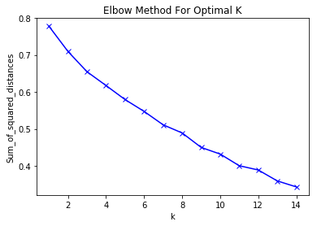

```python
plt.plot(K, Sum_of_squared_distances, 'bx-')
plt.xlabel('k')
plt.ylabel('Sum_of_squared_distances')
plt.title('Elbow Method For Optimal K')
plt.show()
```

#### Let's use k=5

```python
# set number of clusters
kclusters = 5

manhattan_grouped_clustering = manhattan_grouped.drop('Neighborhood', 1)

# run k-means clustering
kmeans = KMeans(n_clusters=kclusters, random_state=0).fit(manhattan_grouped_clustering)

# check cluster labels generated for each row in the dataframe
kmeans.labels_[0:10]
```

```
array([2, 1, 1, 2, 1, 2, 2, 0, 1, 1], dtype=int32)
```

#### Let's create a new dataframe that includes the cluster as well as the top 10 venues for each neighborhood.

```python
# add clustering labels
neighborhoods_venues_sorted.insert(0, 'Cluster Labels', kmeans.labels_)

manhattan_merged = manhattan_data

# merge nyc_grouped with nyc_data to add latitude/longitude for each neighborhood
manhattan_merged = manhattan_merged.join(neighborhoods_venues_sorted.set_index('Neighborhood'), on='Neighborhood')

manhattan_merged.head() # check the last columns!
```

|  | Borough | Neighborhood | Latitude | Longitude | Cluster Labels | 1st Most Common Venue | 2nd Most Common Venue | 3rd Most Common Venue | 4th Most Common Venue | 5th Most Common Venue | 6th Most Common Venue | 7th Most Common Venue | 8th Most Common Venue | 9th Most Common Venue | 10th Most Common Venue |
| --- | --- | --- | --- | --- | --- | --- | --- | --- | --- | --- | --- | --- | --- | --- | --- |
| 0 | Manhattan | Marble Hill | 40.876551 | -73.910660 | 1 | Sandwich Place | Coffee Shop | Yoga Studio | Kids Store | Steakhouse | Miscellaneous Shop | Supplement Shop | Seafood Restaurant | Gym | Tennis Stadium |
| 1 | Manhattan | Chinatown | 40.715618 | -73.994279 | 1 | Chinese Restaurant | Cocktail Bar | Vietnamese Restaurant | American Restaurant | Bakery | Dumpling Restaurant | Salon / Barbershop | Spa | Malay Restaurant | Supermarket |
| 2 | Manhattan | Washington Heights | 40.851903 | -73.936900 | 0 | Café | Bakery | Deli / Bodega | Spanish Restaurant | Mobile Phone Shop | Grocery Store | Park | Restaurant | Latin American Restaurant | Supermarket |
| 3 | Manhattan | Inwood | 40.867684 | -73.921210 | 0 | Café | Mexican Restaurant | Pizza Place | Deli / Bodega | Lounge | Bakery | Pharmacy | Park | Chinese Restaurant | Spanish Restaurant |
| 4 | Manhattan | Hamilton Heights | 40.823604 | -73.949688 | 0 | Pizza Place | Mexican Restaurant | Café | Deli / Bodega | Coffee Shop | Yoga Studio | Liquor Store | Indian Restaurant | Park | Sushi Restaurant |

```python
manhattan_merged.dropna( subset=['Cluster Labels'], axis=0, how='any',inplace=True)
```

#### Finally, let's visualize the resulting clusters

```python
# create map
map_clusters = folium.Map(location=[latitude, longitude], zoom_start=11)

# set color scheme for the clusters
x = np.arange(kclusters)
ys = [i + x + (i*x)**2 for i in range(kclusters)]
colors_array = cm.rainbow(np.linspace(0, 1, len(ys)))
rainbow = [colors.rgb2hex(i) for i in colors_array]

# add markers to the map
markers_colors = []
for lat, lon, poi, cluster in zip(manhattan_merged['Latitude'], manhattan_merged['Longitude'], manhattan_merged['Neighborhood'], manhattan_merged['Cluster Labels']):
    label = folium.Popup(str(poi) + ' Cluster ' + str(cluster), parse_html=True)
    folium.CircleMarker(
        [lat, lon],
        radius=5,
        popup=label,
        color=rainbow[int(cluster)-1],
        fill=True,
        fill_color=rainbow[int(cluster)-1],
        fill_opacity=0.7).add_to(map_clusters)

map_clusters
```

[interactive chart not shown]

# PART 3 - ANALYSIS

Now that we generated the Choropleth and clustered the neighborhoods, let's combine the first 2 parts!

```python
# add markers to the Choropleth
markers_colors = []
for lat, lon, poi, cluster in zip(manhattan_merged['Latitude'], manhattan_merged['Longitude'], manhattan_merged['Neighborhood'], manhattan_merged['Cluster Labels']):
    label = folium.Popup(str(poi) + ' Cluster ' + str(cluster), parse_html=True)
    folium.CircleMarker(
        [lat, lon],
        radius=5,
        popup=label,
        color=rainbow[int(cluster)-1],
        fill=True,
        fill_color=rainbow[int(cluster)-1],
        fill_opacity=0.7).add_to(manhattan_map)

manhattan_map
```

[interactive chart not shown]

## Examine and analyze clusters

Let's examine each cluster and determine the discriminating venue categories that distinguish each cluster. Based on the defining categories, we can then assign a name to each cluster.

#### Cluster 1 - Restaurants

```python
manhattan_merged.loc[manhattan_merged['Cluster Labels'] == 0, manhattan_merged.columns[[1] + list(range(5, manhattan_merged.shape[1]))]]
```

|  | Neighborhood | 1st Most Common Venue | 2nd Most Common Venue | 3rd Most Common Venue | 4th Most Common Venue | 5th Most Common Venue | 6th Most Common Venue | 7th Most Common Venue | 8th Most Common Venue | 9th Most Common Venue | 10th Most Common Venue |
| --- | --- | --- | --- | --- | --- | --- | --- | --- | --- | --- | --- |
| 2 | Washington Heights | Café | Bakery | Deli / Bodega | Spanish Restaurant | Mobile Phone Shop | Grocery Store | Park | Restaurant | Latin American Restaurant | Supermarket |
| 3 | Inwood | Café | Mexican Restaurant | Pizza Place | Deli / Bodega | Lounge | Bakery | Pharmacy | Park | Chinese Restaurant | Spanish Restaurant |
| 4 | Hamilton Heights | Pizza Place | Mexican Restaurant | Café | Deli / Bodega | Coffee Shop | Yoga Studio | Liquor Store | Indian Restaurant | Park | Sushi Restaurant |
| 7 | East Harlem | Mexican Restaurant | Bakery | Deli / Bodega | Latin American Restaurant | Thai Restaurant | Coffee Shop | Gym | Grocery Store | Liquor Store | Park |
| 25 | Manhattan Valley | Coffee Shop | Pizza Place | Indian Restaurant | Mexican Restaurant | Thai Restaurant | Spa | French Restaurant | Deli / Bodega | Yoga Studio | Bar |
| 36 | Tudor City | Café | Mexican Restaurant | Park | Sushi Restaurant | Greek Restaurant | Pizza Place | Deli / Bodega | Garden | Diner | Spanish Restaurant |

#### Cluster 2 - Career

Some of the most common venues in this cluster are:

- Bars, where people hangout after work
- Coffee shops, which is a necessity for office workers
- Restaurants, including Chinese, Japanese, Italian, American, etc., satisfying people's various interests
- Gyms, where office workers love going at least several times a week

Let's say this cluster is best for people who have high-paying jobs (perhaps in Wall Street), and want to be socially and physically fit.

```python
manhattan_merged.loc[manhattan_merged['Cluster Labels'] == 1, manhattan_merged.columns[[1] + list(range(5, manhattan_merged.shape[1]))]]
```

|  | Neighborhood | 1st Most Common Venue | 2nd Most Common Venue | 3rd Most Common Venue | 4th Most Common Venue | 5th Most Common Venue | 6th Most Common Venue | 7th Most Common Venue | 8th Most Common Venue | 9th Most Common Venue | 10th Most Common Venue |
| --- | --- | --- | --- | --- | --- | --- | --- | --- | --- | --- | --- |
| 0 | Marble Hill | Sandwich Place | Coffee Shop | Yoga Studio | Kids Store | Steakhouse | Miscellaneous Shop | Supplement Shop | Seafood Restaurant | Gym | Tennis Stadium |
| 1 | Chinatown | Chinese Restaurant | Cocktail Bar | Vietnamese Restaurant | American Restaurant | Bakery | Dumpling Restaurant | Salon / Barbershop | Spa | Malay Restaurant | Supermarket |
| 5 | Manhattanville | Coffee Shop | Mexican Restaurant | Italian Restaurant | Seafood Restaurant | Park | Food & Drink Shop | Sushi Restaurant | Bar | Liquor Store | Lounge |
| 6 | Central Harlem | African Restaurant | French Restaurant | Public Art | Gym / Fitness Center | Bar | Chinese Restaurant | Seafood Restaurant | Fried Chicken Joint | American Restaurant | Caribbean Restaurant |
| 9 | Yorkville | Bar | Gym | Italian Restaurant | Coffee Shop | Pizza Place | Sushi Restaurant | Deli / Bodega | Mexican Restaurant | Japanese Restaurant | Diner |
| 10 | Lenox Hill | Italian Restaurant | Coffee Shop | Pizza Place | Sushi Restaurant | Café | Gym | Cosmetics Shop | Gym / Fitness Center | Burger Joint | Sporting Goods Shop |
| 12 | Upper West Side | Italian Restaurant | Coffee Shop | Wine Bar | Bakery | Vegetarian / Vegan Restaurant | Bar | Indian Restaurant | American Restaurant | Pet Store | Middle Eastern Restaurant |
| 16 | Murray Hill | Coffee Shop | Japanese Restaurant | Hotel | Sandwich Place | French Restaurant | American Restaurant | Italian Restaurant | Gym | Gym / Fitness Center | Steakhouse |
| 19 | East Village | Bar | Ice Cream Shop | Wine Bar | Mexican Restaurant | Chinese Restaurant | Pizza Place | Cocktail Bar | Ramen Restaurant | Vegetarian / Vegan Restaurant | Japanese Restaurant |
| 20 | Lower East Side | Coffee Shop | Café | Pizza Place | Japanese Restaurant | Ramen Restaurant | Chinese Restaurant | Cocktail Bar | Bakery | Art Gallery | Sandwich Place |
| 26 | Morningside Heights | Park | Coffee Shop | Bookstore | American Restaurant | Deli / Bodega | Tennis Court | Sandwich Place | Food Truck | Burger Joint | Café |
| 27 | Gramercy | Bar | Italian Restaurant | American Restaurant | Pizza Place | Bagel Shop | Thai Restaurant | Cocktail Bar | Thrift / Vintage Store | Grocery Store | Hotel |
| 29 | Financial District | Coffee Shop | Gym | Hotel | Pizza Place | Wine Shop | Gym / Fitness Center | Cocktail Bar | American Restaurant | Steakhouse | Food Truck |
| 30 | Carnegie Hill | Coffee Shop | Pizza Place | Café | Cosmetics Shop | Yoga Studio | Spa | Bakery | Bar | Bookstore | French Restaurant |
| 33 | Midtown South | Korean Restaurant | Hotel Bar | Hotel | Japanese Restaurant | Cosmetics Shop | American Restaurant | Coffee Shop | Dessert Shop | Gym / Fitness Center | Gastropub |
| 34 | Sutton Place | Gym / Fitness Center | Furniture / Home Store | Indian Restaurant | Italian Restaurant | Coffee Shop | American Restaurant | Gym | Dessert Shop | Pizza Place | Yoga Studio |
| 35 | Turtle Bay | Italian Restaurant | Sushi Restaurant | Steakhouse | Wine Bar | Coffee Shop | Japanese Restaurant | Indian Restaurant | French Restaurant | Ramen Restaurant | Café |

#### Cluster 3 - Art

This cluster has 15 neighborhoods and is located in the downtown and midtown. Some renowned neighborhoods in it are Upper East Side, Midtown, Greenwich Village, SoHo, West Village, and Little Italy. The residential apartment sales price is the most expensive among all the neighborhoods. The majority in this neighborhood has a price per square foot from \$1,882 to \\$2,509.

Having Lincoln Square, Clinton, Upper East Side, and SoHo in this cluster, this cluster is the most artistic one among all. This cluster is good for people who value art, want to have a good social life, and like to work out. Some of the most common venues are:

- Italian restaurants
- Theaters
- Gyms
- Clothing/fashion shops

```python
manhattan_merged.loc[manhattan_merged['Cluster Labels'] == 2, manhattan_merged.columns[[1] + list(range(5, manhattan_merged.shape[1]))]]
```

|  | Neighborhood | 1st Most Common Venue | 2nd Most Common Venue | 3rd Most Common Venue | 4th Most Common Venue | 5th Most Common Venue | 6th Most Common Venue | 7th Most Common Venue | 8th Most Common Venue | 9th Most Common Venue | 10th Most Common Venue |
| --- | --- | --- | --- | --- | --- | --- | --- | --- | --- | --- | --- |
| 8 | Upper East Side | Italian Restaurant | Exhibit | Art Gallery | Bakery | Gym / Fitness Center | Coffee Shop | Hotel | Juice Bar | Spa | French Restaurant |
| 13 | Lincoln Square | Theater | Gym / Fitness Center | Italian Restaurant | Café | Concert Hall | Plaza | French Restaurant | Opera House | Performing Arts Venue | Indie Movie Theater |
| 14 | Clinton | Theater | Gym / Fitness Center | Italian Restaurant | American Restaurant | Spa | Wine Shop | Hotel | Mediterranean Restaurant | Gym | Indie Theater |
| 15 | Midtown | Hotel | Clothing Store | Cocktail Bar | Coffee Shop | Theater | Japanese Restaurant | Bakery | Bookstore | Café | Steakhouse |
| 17 | Chelsea | Coffee Shop | Ice Cream Shop | Bakery | Italian Restaurant | Nightclub | Seafood Restaurant | Hotel | American Restaurant | Theater | Bookstore |
| 18 | Greenwich Village | Italian Restaurant | Clothing Store | Sushi Restaurant | French Restaurant | Café | Indian Restaurant | Seafood Restaurant | Chinese Restaurant | Cosmetics Shop | Burger Joint |
| 21 | Tribeca | Park | Italian Restaurant | American Restaurant | Café | Spa | Boutique | Wine Shop | Wine Bar | Coffee Shop | Gym |
| 22 | Little Italy | Bakery | Café | Sandwich Place | Clothing Store | Salon / Barbershop | Mediterranean Restaurant | Thai Restaurant | Hotel | Ice Cream Shop | Yoga Studio |
| 23 | Soho | Clothing Store | Boutique | Art Gallery | Shoe Store | Women's Store | Men's Store | Furniture / Home Store | Italian Restaurant | Mediterranean Restaurant | Sporting Goods Shop |
| 24 | West Village | Italian Restaurant | New American Restaurant | Cosmetics Shop | Jazz Club | American Restaurant | Wine Bar | Park | Cocktail Bar | Bakery | Ice Cream Shop |
| 28 | Battery Park City | Park | Coffee Shop | Hotel | Memorial Site | Gym | Italian Restaurant | Wine Shop | Food Court | Shopping Mall | BBQ Joint |
| 31 | Noho | Italian Restaurant | Cocktail Bar | Art Gallery | French Restaurant | Coffee Shop | Gift Shop | Bookstore | Boutique | Rock Club | Pizza Place |
| 32 | Civic Center | Gym / Fitness Center | Italian Restaurant | Hotel | French Restaurant | Sandwich Place | Coffee Shop | Yoga Studio | Park | American Restaurant | Sporting Goods Shop |
| 38 | Flatiron | Gym / Fitness Center | Yoga Studio | American Restaurant | Gym | Japanese Restaurant | New American Restaurant | Dessert Shop | Cycle Studio | Italian Restaurant | Cosmetics Shop |
| 39 | Hudson Yards | Café | American Restaurant | Italian Restaurant | Gym / Fitness Center | Hotel | Restaurant | Dog Run | Coffee Shop | Park | Ice Cream Shop |

#### Cluster 4 - Stuyvesant Town

This cluster only has one neighborhood, Stuyvesant Town, a historical town. It offers quite a few venues for people to spend their leisure time - bars, playgrounds, and parks. It's a good neighborhood to sip a drink or play sports with friends.

```python
manhattan_merged.loc[manhattan_merged['Cluster Labels'] == 3, manhattan_merged.columns[[1] + list(range(5, manhattan_merged.shape[1]))]]
```

|  | Neighborhood | 1st Most Common Venue | 2nd Most Common Venue | 3rd Most Common Venue | 4th Most Common Venue | 5th Most Common Venue | 6th Most Common Venue | 7th Most Common Venue | 8th Most Common Venue | 9th Most Common Venue | 10th Most Common Venue |
| --- | --- | --- | --- | --- | --- | --- | --- | --- | --- | --- | --- |
| 37 | Stuyvesant Town | Boat or Ferry | Playground | Park | Bar | Gas Station | Pet Service | Fountain | German Restaurant | Bistro | Farmers Market |

#### Cluster 5 - Roosevelt Island

This cluster also has only one neighborhood, Roosevelt Island. As a small island just next by Manhattan island, Roosevelt island is a lot of people's choice when considering buying homes. Compared to other boroughs, the commute from Roosevelt Island to Manhattan island is much more convenient. The most common venues in this cluster also indicate that it's a good neighborhood to live a convenient and normal life.

The apartment sales price ranges from \$1,254 to \\$1,882 per square foot.

```python
manhattan_merged.loc[manhattan_merged['Cluster Labels'] == 4, manhattan_merged.columns[[1] + list(range(5, manhattan_merged.shape[1]))]]
```

|  | Neighborhood | 1st Most Common Venue | 2nd Most Common Venue | 3rd Most Common Venue | 4th Most Common Venue | 5th Most Common Venue | 6th Most Common Venue | 7th Most Common Venue | 8th Most Common Venue | 9th Most Common Venue | 10th Most Common Venue |
| --- | --- | --- | --- | --- | --- | --- | --- | --- | --- | --- | --- |
| 11 | Roosevelt Island | Sandwich Place | Coffee Shop | Japanese Restaurant | Bus Line | Gym | Greek Restaurant | Metro Station | Supermarket | Monument / Landmark | Bridge |